# Analise Estação Meteorologia e Pluviometros

26/02/2020

## Objetivo

Objetivo desse estudo é analisar o comportamento das baterias durante um determinado intervalo de tempo, assim detectando anomalias que podem afetar a sua capacidade de funcionamento e de outros componentes.

## Componente Bateria

- Existem algumas perguntas que podem ser levantadas.
1. Porque a tensão da bateria de alguns ou de outros equipamentos tem uma variação de queda maior durante um curto período de tempo?
2. Porque a bateria para de repente de funcionar?
3. Quais são as melhores baterias que possuem uma tensão quase constante?
4. A temperatura do ambiente afeta a funcionamento da bateria?
5. Quais são os tipos de bateria em que estão ocorrendo mais problemas?
6. Quais são as frêquencias de troca de bateria por equipamento?
7. Quais são os valores médios das tensões das baterias quando foram trocadas?

## Visualização de dados coletados

Grafico de Pizza e de barra mostra a porcentagem e quantidade de dados que foi coletadas nas corporativas.

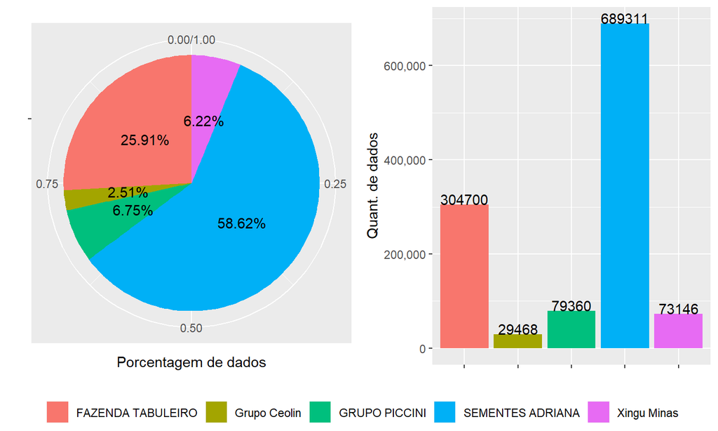

Fonte: [download dataset.db](https://drive.google.com/open?id=1bfa0UBocqtnrY-eBmY_DPz2rxpO_3THL).

## Visualização dos comportamentos das tensões

Grafico ScatterPlot mostrando o comportamento da tensões das baterias dos equipamentos pluviometro e estação meteorologica.

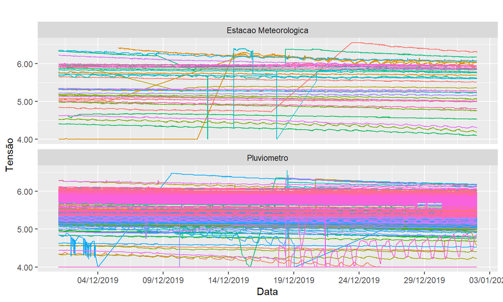

## Visualização de distribuição de tensão

Grafico histogram mostrando onde as tensões estão mais concentradas.

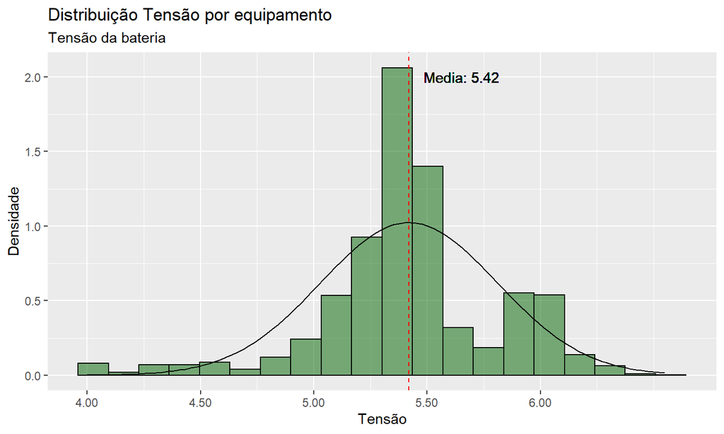

## Coeficiente de Variação e limitação de tensão

Usando a ténica do **CV** para obter apenas os dados que possuem uma grande porcetagem de variação durante os dias. A bateria possui uma limitação de **4.75V** para fornecer um bom funcionamento para os sensores, abaixo disso pode comprometer o funcionamento dos componentes.

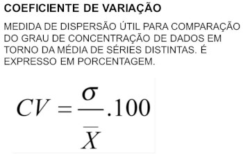

## 1. **FAZENDA TABULEIRO**

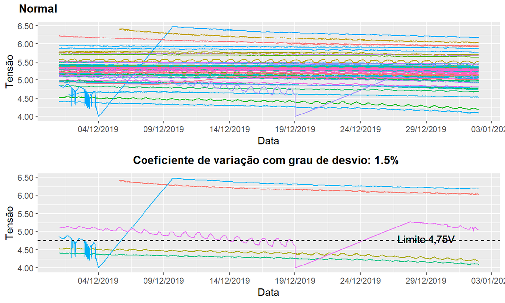

## 2. **Grupo Ceolin**

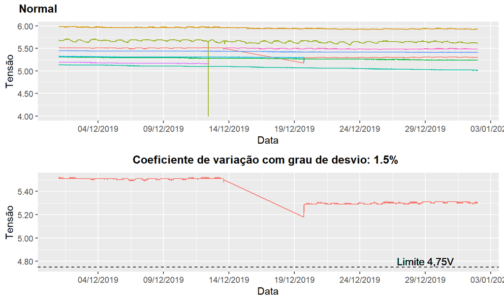

## 4. **SEMENTES ADRIANA**

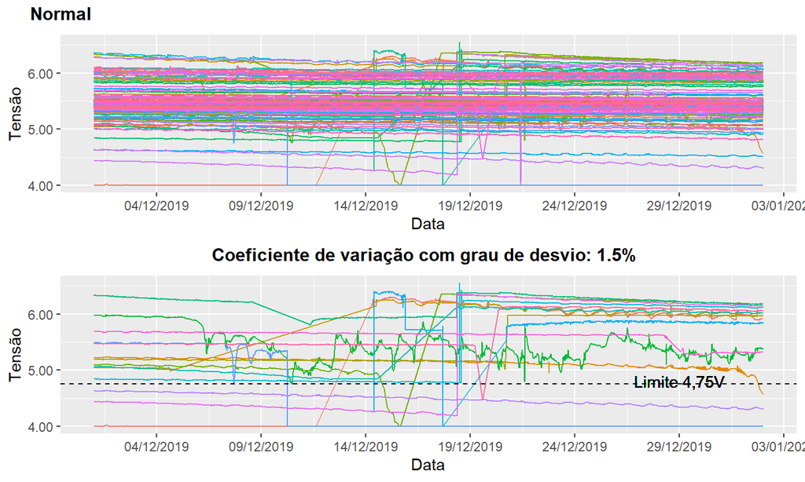

## 5. **Xingu Minas**

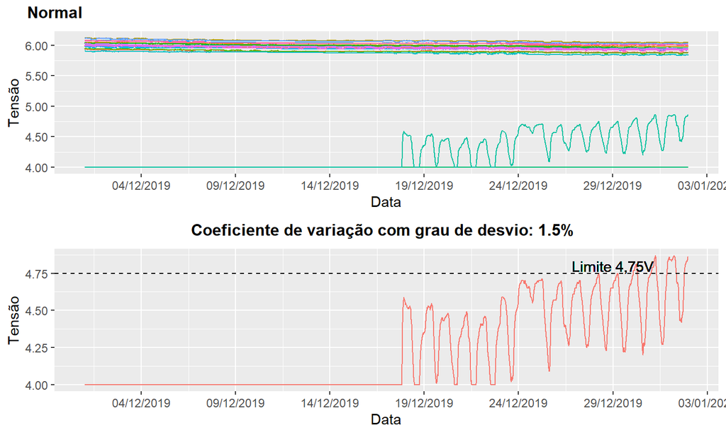

## Visualização de perda de dados.

Alguns dados de tensão não foram transmitidos em sequencia diaria, alguma anomalia pode ter causado essa perda de dados.

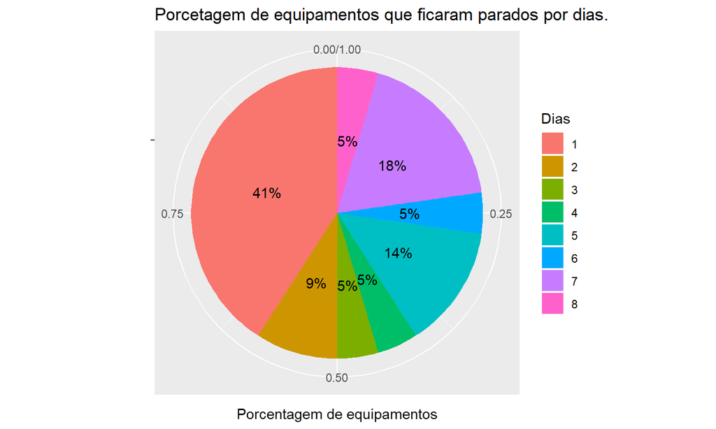

## O que pode ter acontecido?

Essa perda de dados pode ter varios fatores envolvidos, vamos ver alguns deles.

- Manutenção do equipamento no campo.
- Problema de comunicação.
- Remoção da bateria por imprudência do operador.
- Serviço do banco de dados Procedure e Triggers.
- Mal funcionamento das baterias.

Essas ocorrências não são detectaveis pela falta de informação que obtemos, podemos melhorar isso estudando uma nova estrutura de dados para obtermos realmente as causas dos fenomenos.

## Classificação da bateria.

Havíamos mencionado anteriormente (na pagina 8) que para que uma bateria venha a fornecer um bom desempenho para os sensores, limitamos uma tensão de 4.75V e com coeficiente de variação insignificante, baseado nestas informações, classificamos a qualidade da bateria que está presente no equipamento no momento.

Verde = Bateria ótima ou nova (com nível de carga ok)  
Amarelo = Bateria com nível de carga aceitável, porém em observação  
Vermelho = Bateria com nível de carga crítico, necessita ser substituída  
Preto = Bateria morta (equipamentos pode até ainda funcionar com ela, no entanto, possivelmente está emitindo dados errados, devido a falta de capacidade de corrente da bateria)  
Esta precisa ser substituída imediatamente

## Treinamento do modelo

O modelo classisfica qual a qualidade de bateria que o equipamento esta possuindo no momento, para isso obtem a tensão atual e um historico de 8 dias, esses dados são os previsores no qual são passados para o modelo classificado pela probabilidade.

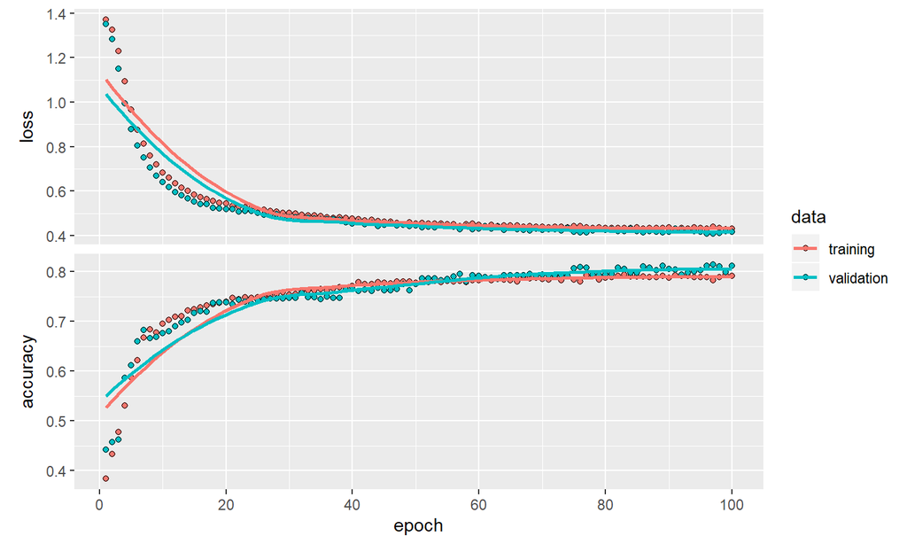

## Testando o modelo

O teste que vamos fazer é baseado no período de 24/12/2019 até 01/01/2020 da corporativa **XINGU_AGRI**.

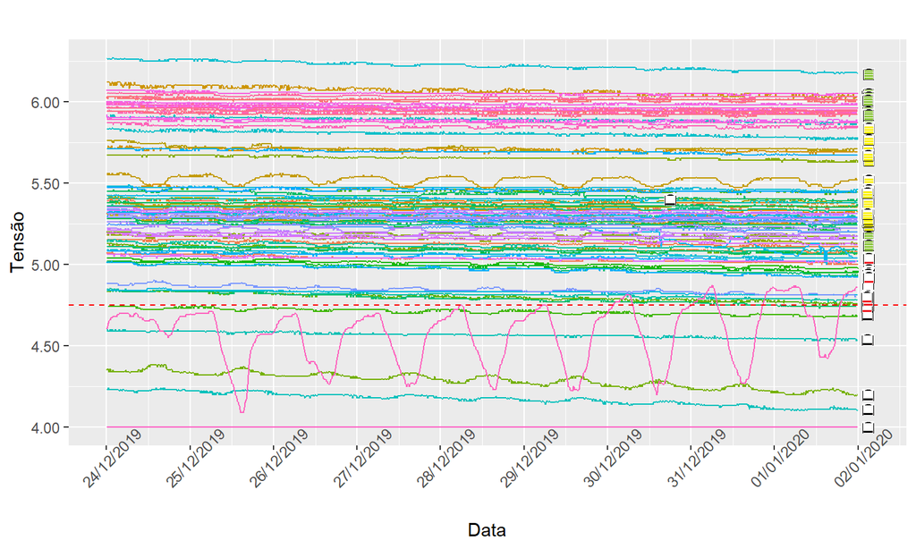

## Resultados da classificação

[figure not shown]

O que fazer com essas informações?

- Alarme
  - Enviar email.
  - Criar um sinal de alerta no mapa através do SGPA.
  - Enviar uma mensagem para os lideres próximos dos equipamentos.
- Inserir em uma tabela do banco.